# loan_01-Copy1

## kaggle : All Lending Club loan data

LendingClub: 도시 고객들에게 다양한 유형의 대출을 전문적으로 제공하는 회사

- 은행 및 금융 서비스 분야의 위험 분석(Risk Analytics)
- 고객에게 대출금을 빌려주는 동안 손실 위험을 최소화하는 데 데이터를 어떻게 사용할지가 중점

회사가 대출 신청을 받으면, 신청자의 프로필을 기반으로 대출 승인 여부를 결정

- 만약 신청자가 대출금을 상환할 가능성이 높다면, 대출을 승인하지 않는 것은 회사에 사업 기회 손실을 가져옴
- 만약 신청자가 대출금을 상환할 가능성이 낮다면(즉, 채무 불이행(부도) 가능성이 높다면), 대출을 승인하는 것은 회사에 재정적 손실을 초래 가능

데이터

- 과거 대출 신청자들에 대한 정보와 그들이 '채무 불이행(부도)'을 했는지 여부
- 목표: 어떤 사람이 채무 불이행할 가능성이 있는지를 나타내는 패턴을 식별하는 것
- -> 패턴을 활용: 대출 거부, 대출 금액 축소, (위험한 신청자에게) 더 높은 이자율로 대출해 주는 등의 조치 취함 등

개인이 대출을 신청할 때, 회사가 취할 수 있는 결정

1. 대출 승인 (Loan accepted) : 아래 3가지 시나리오 가능
- 완전히 상환됨 (Fully Paid): 신청자가 대출금(원금 및 이자)을 전액 상환
- 현재 상환 중 (Current): 신청자가 현재 할부금을 납부하고 있는 중이며, 대출 기간이 아직 끝나지 않음. 이들은 '채무 불이행자'로 분류되지 않음.
- 대손 처리됨 (Charged-off): 신청자가 장기간 제때 할부금을 납부하지 않아 채무 불이행(부도) 상태가 됨
2. 대출 거부 (Loan rejected)
- 회사가 대출을 거부한 경우(예: 신청자가 요구 사항을 충족하지 못함 등)
- 대출이 거부되었기 때문에 해당 신청자들과의 거래 내역이 회사에는 없으므로, 이 데이터는 회사에(그리고 이 데이터셋에도) 포함되어 있지 않음

🎯 비즈니스 목표 (Business Objectives)

- LendingClub은 개인 대출, 사업 대출, 의료 시술 자금 조달 등을 용이하게 하는 가장 큰 온라인 대출 시장입니다. 대출자들은 빠르고 간편한 온라인 인터페이스를 통해 더 낮은 이자율의 대출에 쉽게 접근할 수 있습니다.
- 대부분의 다른 대출 회사들과 마찬가지로, '위험한' 신청자들에게 대출을 제공하는 것이 가장 큰 재정적 손실(신용 손실)의 원인입니다. 신용 손실은 대출자가 빚진 돈을 갚기를 거부하거나 돈을 들고 도주했을 때 대출 기관이 잃는 돈의 양을 의미합니다. 다시 말해, 채무 불이행을 하는 대출자들이 대출 기관에게 가장 큰 손실을 입힙니다. 이 사례에서는 '대손 처리됨(charged-off)'으로 분류된 고객들이 '채무 불이행자(defaulters)'입니다.
- 만약 이러한 위험한 대출 신청자들을 식별할 수 있다면, 그러한 대출을 줄여 신용 손실액을 줄일 수 있습니다. EDA와 머신러닝을 사용하여 이러한 신청자들을 식별하는 것이 이 사례 연구의 목표입니다.
- 즉, 회사는 대출 채무 불이행의 주요 원인(또는 주요 변수)을 이해하고자 합니다. 이는 채무 불이행의 강력한 지표가 되는 변수들을 파악하는 것입니다. 회사는 이 지식을 대출 포트폴리오 및 위험 평가에 활용할 수 있습니다.

```python
# import pandas as pd

# data = pd.read_csv('accepted_2007_to_2018Q4.csv', parse_dates=['issue_d'], date_format='%b-%y', low_memory=False)
# df_c = data.copy()

# data.head()
```

```python
# data.info()
```

## 대조용 원본 데이터 따로 생성

최소한의 전처리만 수행

- 문자형 컬럼들 (object) → 숫자형으로 변환 (Label Encoding)
- 결측치 → 간단한 방식으로 대체 (예: fillna)
- 불필요한 컬럼 (예: id, member_id) 제거

```python
# import pandas as pd
# from sklearn.preprocessing import LabelEncoder

# # 1. ID 컬럼 등 제거 (모델에 의미 없는 열 제거)
# df_c = df_c.drop(['id', 'member_id'], axis=1, errors='ignore')

# # 2. 문자열(object) 컬럼만 추출
# obj_cols = df_c.select_dtypes(include='object').columns

# # 3. 각 문자열 컬럼에 대해 Label Encoding (단순하게)
# for col in obj_cols:
#     df_c[col] = df_c[col].fillna('Missing')  # 결측값을 'Missing'이라는 문자열로 처리
#     le = LabelEncoder()
#     df_c[col] = le.fit_transform(df_c[col])

# # 4. 수치형 결측값은 0으로 대체 (또는 평균, 중간값도 가능)
# df_c = df_c.fillna(0)
```

```python
#df_c.to_csv("lendingclub_minimal_preprocessed.csv", index=False, encoding='utf-8')
```

```python
import pandas as pd

df_c = pd.read_csv("lendingclub_minimal_preprocessed.csv", encoding='utf-8')
df_c.head()
```

|  | loan_amnt | funded_amnt | funded_amnt_inv | term | int_rate | installment | grade | sub_grade | emp_title | emp_length | ... | hardship_payoff_balance_amount | hardship_last_payment_amount | disbursement_method | debt_settlement_flag | debt_settlement_flag_date | settlement_status | settlement_date | settlement_amount | settlement_percentage | settlement_term |
| --- | --- | --- | --- | --- | --- | --- | --- | --- | --- | --- | --- | --- | --- | --- | --- | --- | --- | --- | --- | --- | --- |
| 0 | 3600.0 | 3600.0 | 3600.0 | 0 | 13.99 | 123.03 | 2 | 13 | 479209 | 1 | ... | 0.0 | 0.0 | 0 | 1 | 60 | 3 | 68 | 0.0 | 0.0 | 0.0 |
| 1 | 24700.0 | 24700.0 | 24700.0 | 0 | 11.99 | 820.28 | 2 | 10 | 141409 | 1 | ... | 0.0 | 0.0 | 0 | 1 | 60 | 3 | 68 | 0.0 | 0.0 | 0.0 |
| 2 | 20000.0 | 20000.0 | 20000.0 | 1 | 10.78 | 432.66 | 1 | 8 | 508568 | 1 | ... | 0.0 | 0.0 | 0 | 1 | 60 | 3 | 68 | 0.0 | 0.0 | 0.0 |
| 3 | 35000.0 | 35000.0 | 35000.0 | 1 | 14.85 | 829.90 | 2 | 14 | 199294 | 1 | ... | 0.0 | 0.0 | 0 | 1 | 60 | 3 | 68 | 0.0 | 0.0 | 0.0 |
| 4 | 10400.0 | 10400.0 | 10400.0 | 1 | 22.45 | 289.91 | 5 | 25 | 91957 | 3 | ... | 0.0 | 0.0 | 0 | 1 | 60 | 3 | 68 | 0.0 | 0.0 | 0.0 |

5 rows × 149 columns

```python
df_c.info()
```

```
<class 'pandas.core.frame.DataFrame'>
RangeIndex: 2260701 entries, 0 to 2260700
Columns: 149 entries, loan_amnt to settlement_term
dtypes: float64(112), int64(37)
memory usage: 2.5 GB
```

## 전처리 완전히 완료된 파일 -> CSV 저장

```python
# data.to_csv("lendingclub_processed1.csv", index=False, encoding='utf-8')
```

```python
data = pd.read_csv("lendingclub_processed1.csv", encoding='utf-8')
data.head()
```

|  | loan_amnt | term | int_rate | installment | emp_length | issue_d | dti | earliest_cr_line | open_acc | pub_rec | ... | addr_state_TX | addr_state_UT | addr_state_VA | addr_state_VT | addr_state_WA | addr_state_WI | addr_state_WV | addr_state_WY | initial_list_status_w | application_type_Joint App |
| --- | --- | --- | --- | --- | --- | --- | --- | --- | --- | --- | --- | --- | --- | --- | --- | --- | --- | --- | --- | --- | --- |
| 0 | 3600.0 | 36 | 13.99 | 123.03 | 10.0 | Dec-2015 | 5.91 | 2003 | 7 | 0.0 | ... | False | False | False | False | False | False | False | False | True | False |
| 1 | 24700.0 | 36 | 11.99 | 820.28 | 10.0 | Dec-2015 | 16.06 | 1999 | 22 | 0.0 | ... | False | False | False | False | False | False | False | False | True | False |
| 2 | 20000.0 | 60 | 10.78 | 432.66 | 10.0 | Dec-2015 | 10.78 | 2000 | 6 | 0.0 | ... | False | False | False | False | False | False | False | False | True | True |
| 3 | 10400.0 | 60 | 22.45 | 289.91 | 3.0 | Dec-2015 | 25.37 | 1998 | 12 | 0.0 | ... | False | False | False | False | False | False | False | False | True | False |
| 4 | 11950.0 | 36 | 13.44 | 405.18 | 4.0 | Dec-2015 | 10.20 | 1987 | 5 | 0.0 | ... | False | False | False | False | False | False | False | False | True | False |

5 rows × 122 columns

```python
data.info()
```

```
<class 'pandas.core.frame.DataFrame'>
RangeIndex: 1345310 entries, 0 to 1345309
Columns: 122 entries, loan_amnt to application_type_Joint App
dtypes: bool(104), float64(13), int64(4), object(1)
memory usage: 318.2+ MB
```

### (3) 훈련/테스트 데이터 나누기

```python
data['issue_d'].sample(5)
```

```
779789     Jul-2014
741152     Sep-2014
1306628    Nov-2016
734730     Oct-2014
1158245    Oct-2012
Name: issue_d, dtype: object
```

```python
data['issue_d'].isnull().any()
```

```
False
```

```python
data['issue_d'] = pd.to_datetime(data['issue_d'])
```

```python
data['issue_d'].sample(5)
```

```
1073427   2013-08-01
1033052   2013-11-01
1343068   2016-10-01
1108912   2013-04-01
244824    2015-05-01
Name: issue_d, dtype: datetime64[ns]
```

```python
data['issue_d'].describe()
```

```
count                          1345310
mean     2015-06-06 17:48:20.835048960
min                2007-06-01 00:00:00
25%                2014-07-01 00:00:00
50%                2015-08-01 00:00:00
75%                2016-07-01 00:00:00
max                2018-12-01 00:00:00
Name: issue_d, dtype: object
```

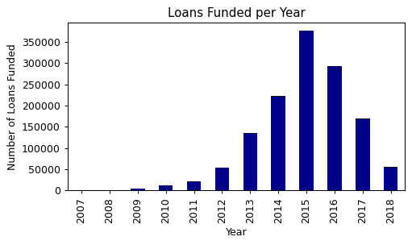

```python
import matplotlib.pyplot as plt

plt.figure(figsize=(6,3), dpi=90)
data['issue_d'].dt.year.value_counts().sort_index().plot.bar(color='darkblue')
plt.xlabel('Year')
plt.ylabel('Number of Loans Funded')
plt.title('Loans Funded per Year')
```

```python
loans_train = data.loc[data['issue_d'] <  data['issue_d'].quantile(0.9)]
loans_test =  data.loc[data['issue_d'] >= data['issue_d'].quantile(0.9)]
```

```python
print('Number of loans in the partition:   ', loans_train.shape[0] + loans_test.shape[0])
print('Number of loans in the full dataset:', data.shape[0])
```

```
Number of loans in the partition:    1345310
Number of loans in the full dataset: 1345310
```

```python
loans_test.shape[0] / data.shape[0]
```

```
0.11111639696426846
```

```python
del data
```

```python
loans_train['issue_d'].describe()
```

```
count                          1195824
mean     2015-02-14 03:13:47.495684864
min                2007-06-01 00:00:00
25%                2014-05-01 00:00:00
50%                2015-06-01 00:00:00
75%                2016-03-01 00:00:00
max                2017-05-01 00:00:00
Name: issue_d, dtype: object
```

```python
loans_test['issue_d'].describe()
```

```
count                           149486
mean     2017-11-23 13:15:22.119796992
min                2017-06-01 00:00:00
25%                2017-08-01 00:00:00
50%                2017-11-01 00:00:00
75%                2018-03-01 00:00:00
max                2018-12-01 00:00:00
Name: issue_d, dtype: object
```

```python
loans_train.drop('issue_d', axis=1, inplace=True)
loans_test.drop('issue_d', axis=1, inplace=True)
```

```python
y_train = loans_train['charged_off']
y_test = loans_test['charged_off']
```

```python
X_train = loans_train.drop('charged_off', axis=1)
X_test = loans_test.drop('charged_off', axis=1)
```

```python
del loans_train, loans_test
```

```python
# 입력 데이터 (Features)
#X_train.to_csv("lendingclub_processed1_X_train.csv", index=False, encoding='utf-8')
#X_test.to_csv("lendingclub_processed1_X_test.csv", index=False, encoding='utf-8')

# 타깃 변수 (Labels)
#y_train.to_csv("lendingclub_processed1_y_train.csv", index=False, encoding='utf-8')
#y_test.to_csv("lendingclub_processed1_y_test.csv", index=False, encoding='utf-8')
```

## target(charged_off)과 피쳐 간의 선형 상관관계 분석

```python
linear_dep = pd.DataFrame()
```

피어슨 상관계수

- -1 ~ 1 사이 값으로, 절댓값이 클수록 강한 선형 관계

```python
for col in X_train.columns:
    linear_dep.loc[col, 'pearson_corr'] = X_train[col].corr(y_train)
linear_dep['abs_pearson_corr'] = abs(linear_dep['pearson_corr'])
```

F-통계량

- (각 변수와 charged_off 간 분산분석(ANOVA)을 수행)
- F 값은 그룹 간 차이가 유의미한지를 나타냄
- p_value는 그 유의성의 확률값(작을수록 유의미함)
- (결측치가 없는 부분만 사용해 계산)

```python
from sklearn.feature_selection import f_classif
for col in X_train.columns:
    mask = X_train[col].notnull()
    (linear_dep.loc[col, 'F'], linear_dep.loc[col, 'p_value']) = f_classif(pd.DataFrame(X_train.loc[mask, col]), y_train.loc[mask])
```

- 피어슨 상관계수의 절대값에 따라 정렬

```python
linear_dep.sort_values('abs_pearson_corr', ascending=False, inplace=True)
linear_dep.drop('abs_pearson_corr', axis=1, inplace=True)
```

```python
# index 리셋
linear_dep.reset_index(inplace=True)
linear_dep.rename(columns={'index':'variable'}, inplace=True)
```

- target과 상관관계 강한 상위 20개 변수

```python
linear_dep.head(20)
```

|  | variable | pearson_corr | F | p_value |
| --- | --- | --- | --- | --- |
| 0 | int_rate | 0.260727 | 87219.488733 | 0.0 |
| 1 | term | 0.182364 | 41137.034592 | 0.0 |
| 2 | fico_score | -0.131392 | 21007.091229 | 0.0 |
| 3 | dti | 0.100747 | 12261.190248 | 0.0 |
| 4 | mort_acc | -0.072414 | 6054.501347 | 0.0 |
| 5 | sub_grade_A4 | -0.065653 | 5176.669917 | 0.0 |
| 6 | log_annual_inc | -0.065324 | 5124.653113 | 0.0 |
| 7 | sub_grade_A5 | -0.065204 | 5105.863849 | 0.0 |
| 8 | sub_grade_A2 | -0.063053 | 4773.117611 | 0.0 |
| 9 | home_ownership_RENT | 0.062418 | 4677.205362 | 0.0 |
| 10 | loan_amnt | 0.061936 | 4604.922425 | 0.0 |
| 11 | verification_status_Verified | 0.061596 | 4554.216117 | 0.0 |
| 12 | sub_grade_A3 | -0.060058 | 4328.943580 | 0.0 |
| 13 | sub_grade_E2 | 0.057561 | 3975.306806 | 0.0 |
| 14 | sub_grade_E4 | 0.056855 | 3878.029274 | 0.0 |
| 15 | sub_grade_E1 | 0.056649 | 3849.945035 | 0.0 |
| 16 | sub_grade_B1 | -0.056570 | 3839.059745 | 0.0 |
| 17 | revol_util | 0.056371 | 3809.925130 | 0.0 |
| 18 | sub_grade_E3 | 0.056314 | 3804.304221 | 0.0 |
| 19 | sub_grade_E5 | 0.055649 | 3714.784458 | 0.0 |

- target과 상관관계 약한 하위 20개 변수

```python
linear_dep.tail(20)
```

|  | variable | pearson_corr | F | p_value |
| --- | --- | --- | --- | --- |
| 100 | addr_state_WY | -0.003484 | 14.512058 | 0.000139 |
| 101 | addr_state_KY | 0.003284 | 12.899558 | 0.000329 |
| 102 | addr_state_RI | -0.003236 | 12.524695 | 0.000402 |
| 103 | addr_state_NC | 0.003228 | 12.462234 | 0.000415 |
| 104 | addr_state_NM | 0.002456 | 7.211381 | 0.007244 |
| 105 | purpose_renewable_energy | 0.002105 | 5.297637 | 0.021355 |
| 106 | addr_state_TX | -0.001797 | 3.853799 | 0.049634 |
| 107 | addr_state_SD | 0.001611 | 3.102581 | 0.078169 |
| 108 | addr_state_MI | 0.001250 | 1.865744 | 0.171964 |
| 109 | purpose_vacation | -0.001205 | 1.737135 | 0.187502 |
| 110 | purpose_educational | -0.001136 | 1.543070 | 0.214162 |
| 111 | addr_state_ND | 0.000954 | 1.088344 | 0.296839 |
| 112 | addr_state_AZ | -0.000837 | 0.837571 | 0.360092 |
| 113 | addr_state_HI | 0.000746 | 0.666534 | 0.414263 |
| 114 | addr_state_VA | 0.000568 | 0.384073 | 0.535431 |
| 115 | addr_state_MN | -0.000494 | 0.292784 | 0.588442 |
| 116 | home_ownership_OTHER | -0.000375 | 0.167771 | 0.682100 |
| 117 | addr_state_IA | -0.000342 | 0.139555 | 0.708724 |
| 118 | addr_state_DE | 0.000162 | 0.031243 | 0.859699 |
| 119 | addr_state_ID | 0.000015 | 0.000284 | 0.986557 |

- 상관관계가 높은 변수: 이자율, 대출 기간(만기), FICO 점수, 소득 대비 부채 비율, 모기지 건수, 소득, 대출 등급, 대출 금액
- 상관관계 낮은 변수: 대출자의 거주 상태, 회전 잔액 및 대출 목적

```python
#linear_dep.to_csv("lendingclub_processed1_linear_dep.csv", index=False, encoding='utf-8')
```

## 모델 훈련 및 테스트

- 모델: Logistic Regression, Random Forest, k-Nearest Neighbors
- 성능 지표: AUROC (Area Under Receiver Operating Characteristic curve) 점수

```python
from sklearn.pipeline import Pipeline
from sklearn.preprocessing import StandardScaler
from sklearn.impute import SimpleImputer
from sklearn.discriminant_analysis import LinearDiscriminantAnalysis
from sklearn.model_selection import GridSearchCV
```

1. 다양한 지표 모두 산출/활용 : roc_auc, auc-pr, precision, recall, f1-score, confusion matrix, precision-recall curve, roc curve (confusion matrix는 표 형태로 출력. precision-recall curve와 roc curve는 그래프로 그리기.)
2. 훈련을 돌때마다 train, test 데이터에 대해 찍히는 성능(지표. ex. roc_auc와 손실 등.)이 어떻게 달라지는지 선그래프 그리기

### (1) 로지스틱 회귀 (+ SGD 학습)

- SGDClassifier : 확률적 경사 하강법(SGD)을 이용해 선형 분류기를 훈련

```python
# from sklearn.linear_model import SGDClassifier
# from sklearn.pipeline import Pipeline
# from sklearn.impute import SimpleImputer
# from sklearn.preprocessing import StandardScaler
# from sklearn.metrics import roc_auc_score

# # ✅ 최적 파라미터 (Optuna 결과 기반)
# best_alpha = 0.006786309313139905
# best_penalty = 'l2'

# # ✅ 파이프라인 구성
# pipeline = Pipeline([
#     ('imputer', SimpleImputer(copy=False)),
#     ('scaler', StandardScaler(copy=False)),
#     ('model', SGDClassifier(
#         loss='log_loss',
#         alpha=best_alpha,
#         penalty=best_penalty,
#         max_iter=1000,
#         tol=1e-3,
#         random_state=1
#     ))
# ])

# # ✅ 학습
# pipeline.fit(X_train, y_train)

# # ✅ 예측 (확률값)
# y_pred_proba = pipeline.predict_proba(X_test)[:, 1]

# # ✅ 평가 (ROC AUC)
# from sklearn.metrics import roc_auc_score
# auc = roc_auc_score(y_test, y_pred_proba)
# print(f"✅ Test ROC AUC: {auc:.4f}")
```

```python
# import numpy as np
# import pandas as pd
# import matplotlib.pyplot as plt
# from sklearn.linear_model import SGDClassifier
# from sklearn.pipeline import Pipeline
# from sklearn.impute import SimpleImputer
# from sklearn.preprocessing import StandardScaler
# from sklearn.metrics import (
#     roc_auc_score, average_precision_score,
#     precision_score, recall_score, f1_score,
#     confusion_matrix, ConfusionMatrixDisplay,
#     roc_curve, precision_recall_curve
# )

# # ✅ 최적 파라미터
# best_alpha_10 = 0.006786309313139905
# best_penalty_10 = 'l2'

# # ✅ 파이프라인 구성
# pipeline_10 = Pipeline([
#     ('imputer', SimpleImputer(copy=False)),
#     ('scaler', StandardScaler(copy=False)),
#     ('model', SGDClassifier(
#         loss='log_loss',
#         alpha=best_alpha_10,
#         penalty=best_penalty_10,
#         max_iter=1,
#         warm_start=True,
#         random_state=1
#     ))
# ])

# # ✅ 초기 전처리 (fit_transform)
# X_train_proc_10 = pipeline_10.named_steps['imputer'].fit_transform(X_train)
# X_train_proc_10 = pipeline_10.named_steps['scaler'].fit_transform(X_train_proc_10)
# X_test_proc_10 = pipeline_10.named_steps['imputer'].transform(X_test)
# X_test_proc_10 = pipeline_10.named_steps['scaler'].transform(X_test_proc_10)

# # ✅ 모델 객체
# model_10 = pipeline_10.named_steps['model']

# # ✅ 반복 학습 및 성능 기록
# epochs_10 = 30
# train_aucs_10, test_aucs_10 = [], []

# for epoch_10 in range(epochs_10):
#     model_10.fit(X_train_proc_10, y_train)

#     y_train_prob_10 = model_10.predict_proba(X_train_proc_10)[:, 1]
#     y_test_prob_10 = model_10.predict_proba(X_test_proc_10)[:, 1]

#     train_aucs_10.append(roc_auc_score(y_train, y_train_prob_10))
#     test_aucs_10.append(roc_auc_score(y_test, y_test_prob_10))

# # ✅ 최종 예측 및 평가
# y_pred_prob_10 = model_10.predict_proba(X_test_proc_10)[:, 1]
# y_pred_10 = model_10.predict(X_test_proc_10)

# # ✅ 지표 계산
# roc_auc_10 = roc_auc_score(y_test, y_pred_prob_10)
# pr_auc_10 = average_precision_score(y_test, y_pred_prob_10)
# precision_10 = precision_score(y_test, y_pred_10)
# recall_10 = recall_score(y_test, y_pred_10)
# f1_10 = f1_score(y_test, y_pred_10)
# cm_10 = confusion_matrix(y_test, y_pred_10)

# # ✅ 결과 출력
# print(f"✅ ROC AUC: {roc_auc_10:.4f}")
# print(f"✅ PR AUC: {pr_auc_10:.4f}")
# print(f"✅ Precision: {precision_10:.4f}")
# print(f"✅ Recall: {recall_10:.4f}")
# print(f"✅ F1 Score: {f1_10:.4f}")
# print("\n📊 Confusion Matrix:")
# print(cm_10)

# # ✅ Confusion Matrix 시각화
# disp_10 = ConfusionMatrixDisplay(confusion_matrix=cm_10)
# disp_10.plot(cmap="Blues")
# plt.title("Confusion Matrix")
# plt.show()

# # ✅ ROC Curve
# fpr_10, tpr_10, _ = roc_curve(y_test, y_pred_prob_10)
# plt.plot(fpr_10, tpr_10, label=f"ROC AUC = {roc_auc_10:.4f}")
# plt.plot([0, 1], [0, 1], 'k--')
# plt.xlabel("False Positive Rate")
# plt.ylabel("True Positive Rate")
# plt.title("ROC Curve")
# plt.legend()
# plt.grid(True)
# plt.show()

# # ✅ Precision-Recall Curve
# prec_10, rec_10, _ = precision_recall_curve(y_test, y_pred_prob_10)
# plt.plot(rec_10, prec_10, label=f"PR AUC = {pr_auc_10:.4f}")
# plt.xlabel("Recall")
# plt.ylabel("Precision")
# plt.title("Precision-Recall Curve")
# plt.legend()
# plt.grid(True)
# plt.show()

# # ✅ 학습 중 성능 변화 시각화
# plt.plot(range(1, epochs_10 + 1), train_aucs_10, label="Train ROC AUC")
# plt.plot(range(1, epochs_10 + 1), test_aucs_10, label="Test ROC AUC")
# plt.xlabel("Epoch")
# plt.ylabel("ROC AUC")
# plt.title("ROC AUC Over Epochs")
# plt.legend()
# plt.grid(True)
# plt.show()
```

```
✅ ROC AUC: 0.7038
✅ PR AUC: 0.3546
✅ Precision: 0.4746
✅ Recall: 0.0964
✅ F1 Score: 0.1602

📊 Confusion Matrix:
[[115971   3232]
 [ 27364   2919]]
```

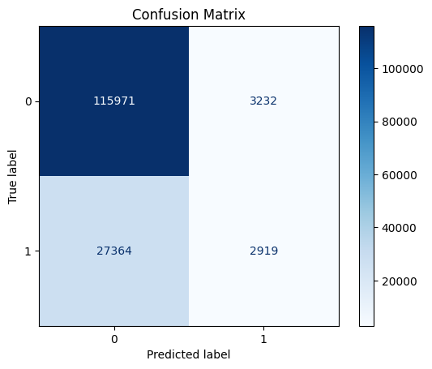

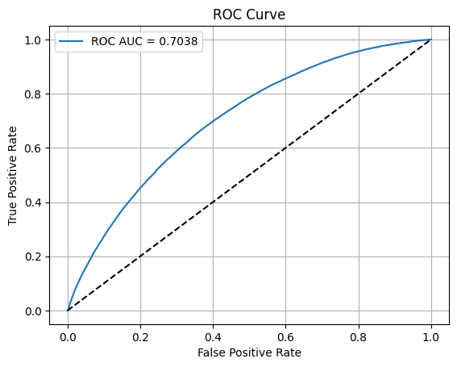

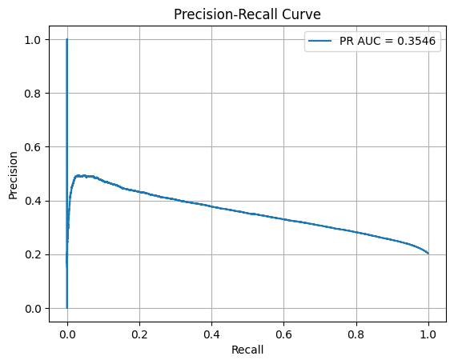

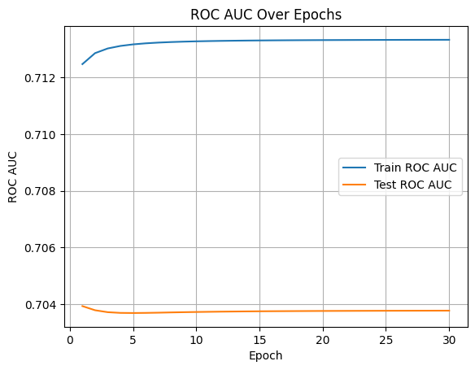

```python
import numpy as np
import pandas as pd
import matplotlib.pyplot as plt
from sklearn.linear_model import SGDClassifier
from sklearn.pipeline import Pipeline
from sklearn.impute import SimpleImputer
from sklearn.preprocessing import StandardScaler
from sklearn.metrics import (
    roc_auc_score, average_precision_score,
    precision_score, recall_score, f1_score,
    confusion_matrix, ConfusionMatrixDisplay,
    roc_curve, precision_recall_curve
)

# ✅ 최적 파라미터
best_alpha_40 = 0.006786309313139905
best_penalty_40 = 'l2'

# ✅ 파이프라인 구성 (전처리 + 모델)
pipeline_40 = Pipeline([
    ('imputer', SimpleImputer(copy=False)),
    ('scaler', StandardScaler(copy=False)),
    ('model', SGDClassifier(
        loss='log_loss',
        alpha=best_alpha_40,
        penalty=best_penalty_40,
        max_iter=1,           # 1 iteration per partial_fit call
        warm_start=True,
        random_state=1
    ))
])

# ✅ 초기 전처리: imputer와 scaler는 pipeline 밖에서 따로 fit_transform 수행
X_train_proc_40 = pipeline_40.named_steps['imputer'].fit_transform(X_train)
X_train_proc_40 = pipeline_40.named_steps['scaler'].fit_transform(X_train_proc_40)
X_test_proc_40 = pipeline_40.named_steps['imputer'].transform(X_test)
X_test_proc_40 = pipeline_40.named_steps['scaler'].transform(X_test_proc_40)

# ✅ 모델 객체 분리
model_40 = pipeline_40.named_steps['model']

# 클래스 정보 필요 (partial_fit에서)
classes_40 = np.unique(y_train)

# 반복 학습 및 성능 기록용 리스트
epochs_40 = 30
train_aucs_40, test_aucs_40 = [], []

for epoch_40 in range(epochs_40):
    model_40.partial_fit(X_train_proc_40, y_train, classes=classes_40)

    y_train_prob_40 = model_40.predict_proba(X_train_proc_40)[:, 1]
    y_test_prob_40 = model_40.predict_proba(X_test_proc_40)[:, 1]

    train_aucs_40.append(roc_auc_score(y_train, y_train_prob_40))
    test_aucs_40.append(roc_auc_score(y_test, y_test_prob_40))

# ✅ 최종 예측 및 클래스 예측
y_pred_prob_40 = model_40.predict_proba(X_test_proc_40)[:, 1]
y_pred_40 = model_40.predict(X_test_proc_40)

# ✅ 평가 지표 계산
roc_auc_40 = roc_auc_score(y_test, y_pred_prob_40)
pr_auc_40 = average_precision_score(y_test, y_pred_prob_40)
precision_40 = precision_score(y_test, y_pred_40)
recall_40 = recall_score(y_test, y_pred_40)
f1_40 = f1_score(y_test, y_pred_40)
cm_40 = confusion_matrix(y_test, y_pred_40)

# ✅ 결과 출력
print(f"✅ ROC AUC: {roc_auc_40:.4f}")
print(f"✅ PR AUC: {pr_auc_40:.4f}")
print(f"✅ Precision: {precision_40:.4f}")
print(f"✅ Recall: {recall_40:.4f}")
print(f"✅ F1 Score: {f1_40:.4f}")
print("\n📊 Confusion Matrix:")
print(cm_40)

# ✅ Confusion Matrix 시각화
disp_40 = ConfusionMatrixDisplay(confusion_matrix=cm_40)
disp_40.plot(cmap="Blues")
plt.title("Confusion Matrix")
plt.show()

# ✅ ROC Curve 시각화
fpr_40, tpr_40, _ = roc_curve(y_test, y_pred_prob_40)
plt.plot(fpr_40, tpr_40, label=f"ROC AUC = {roc_auc_40:.4f}")
plt.plot([0, 1], [0, 1], 'k--')
plt.xlabel("False Positive Rate")
plt.ylabel("True Positive Rate")
plt.title("ROC Curve")
plt.legend()
plt.grid(True)
plt.show()

# ✅ Precision-Recall Curve 시각화
prec_40, rec_40, _ = precision_recall_curve(y_test, y_pred_prob_40)
plt.plot(rec_40, prec_40, label=f"PR AUC = {pr_auc_40:.4f}")
plt.xlabel("Recall")
plt.ylabel("Precision")
plt.title("Precision-Recall Curve")
plt.legend()
plt.grid(True)
plt.show()

# ✅ 학습 중 성능 변화 시각화 (Train/Test ROC AUC)
plt.plot(range(1, epochs_40 + 1), train_aucs_40, label="Train ROC AUC")
plt.plot(range(1, epochs_40 + 1), test_aucs_40, label="Test ROC AUC")
plt.xlabel("Epoch")
plt.ylabel("ROC AUC")
plt.title("ROC AUC Over Epochs")
plt.legend()
plt.grid(True)
plt.show()
```

```
✅ ROC AUC: 0.7037
✅ PR AUC: 0.3547
✅ Precision: 0.4740
✅ Recall: 0.0959
✅ F1 Score: 0.1595

📊 Confusion Matrix:
            Predicted Neg  Predicted Pos
Actual Neg         115981           3222
Actual Pos          27379           2904
```

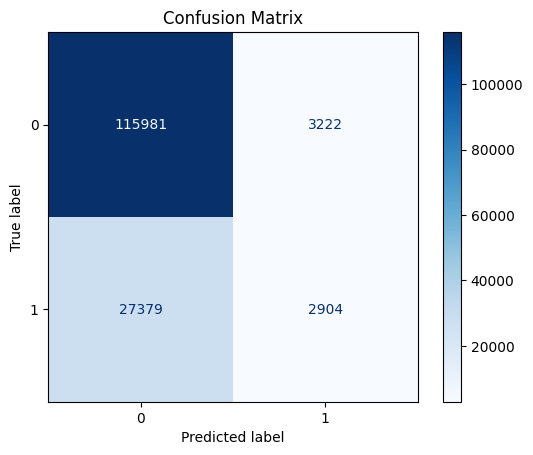

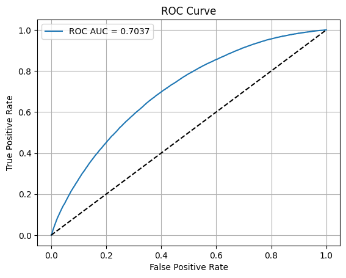

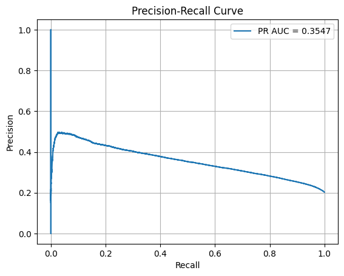

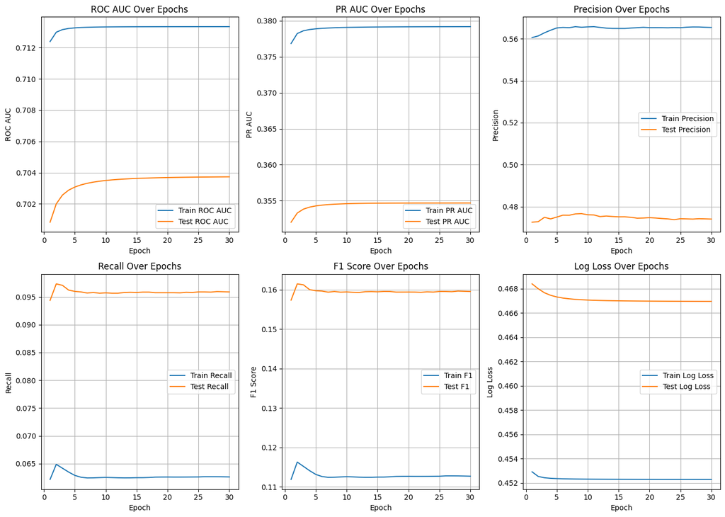

```python
import numpy as np
import pandas as pd
import matplotlib.pyplot as plt
from sklearn.linear_model import SGDClassifier
from sklearn.pipeline import Pipeline
from sklearn.impute import SimpleImputer
from sklearn.preprocessing import StandardScaler
from sklearn.metrics import (
    roc_auc_score, average_precision_score,
    precision_score, recall_score, f1_score,
    confusion_matrix, ConfusionMatrixDisplay,
    roc_curve, precision_recall_curve,
    log_loss
)

# ✅ 최적 파라미터
best_alpha_40 = 0.006786309313139905
best_penalty_40 = 'l2'

# ✅ 파이프라인 구성 (전처리 + 모델)
pipeline_40 = Pipeline([
    ('imputer', SimpleImputer(copy=False)),
    ('scaler', StandardScaler(copy=False)),
    ('model', SGDClassifier(
        loss='log_loss',
        alpha=best_alpha_40,
        penalty=best_penalty_40,
        max_iter=1,
        warm_start=True,
        random_state=42
    ))
])

# ✅ 전처리 수동 수행
X_train_proc_40 = pipeline_40.named_steps['imputer'].fit_transform(X_train)
X_train_proc_40 = pipeline_40.named_steps['scaler'].fit_transform(X_train_proc_40)
X_test_proc_40 = pipeline_40.named_steps['imputer'].transform(X_test)
X_test_proc_40 = pipeline_40.named_steps['scaler'].transform(X_test_proc_40)

# ✅ 모델 객체 및 클래스 정보
model_40 = pipeline_40.named_steps['model']
classes_40 = np.unique(y_train)

# ✅ 기록용 리스트 초기화
epochs_40 = 30
train_aucs_40, test_aucs_40 = [], []
train_pr_aucs, test_pr_aucs = [], []
train_precisions, test_precisions = [], []
train_recalls, test_recalls = [], []
train_f1s, test_f1s = [], []
train_losses, test_losses = [], []

# ✅ 반복 학습
for epoch_40 in range(epochs_40):
    model_40.partial_fit(X_train_proc_40, y_train, classes=classes_40)

    y_train_prob = model_40.predict_proba(X_train_proc_40)[:, 1]
    y_test_prob = model_40.predict_proba(X_test_proc_40)[:, 1]
    y_train_pred = model_40.predict(X_train_proc_40)
    y_test_pred = model_40.predict(X_test_proc_40)

    # ✅ 지표 기록
    train_aucs_40.append(roc_auc_score(y_train, y_train_prob))
    test_aucs_40.append(roc_auc_score(y_test, y_test_prob))

    train_pr_aucs.append(average_precision_score(y_train, y_train_prob))
    test_pr_aucs.append(average_precision_score(y_test, y_test_prob))

    train_precisions.append(precision_score(y_train, y_train_pred))
    test_precisions.append(precision_score(y_test, y_test_pred))

    train_recalls.append(recall_score(y_train, y_train_pred))
    test_recalls.append(recall_score(y_test, y_test_pred))

    train_f1s.append(f1_score(y_train, y_train_pred))
    test_f1s.append(f1_score(y_test, y_test_pred))

    train_losses.append(log_loss(y_train, y_train_prob))
    test_losses.append(log_loss(y_test, y_test_prob))

# ✅ 최종 예측
y_pred_prob_40 = model_40.predict_proba(X_test_proc_40)[:, 1]
y_pred_40 = model_40.predict(X_test_proc_40)

# ✅ 최종 평가 지표
roc_auc_40 = roc_auc_score(y_test, y_pred_prob_40)
pr_auc_40 = average_precision_score(y_test, y_pred_prob_40)
precision_40 = precision_score(y_test, y_pred_40)
recall_40 = recall_score(y_test, y_pred_40)
f1_40 = f1_score(y_test, y_pred_40)
cm_40 = confusion_matrix(y_test, y_pred_40)

# ✅ 평가 출력
print(f"✅ ROC AUC: {roc_auc_40:.4f}")
print(f"✅ PR AUC: {pr_auc_40:.4f}")
print(f"✅ Precision: {precision_40:.4f}")
print(f"✅ Recall: {recall_40:.4f}")
print(f"✅ F1 Score: {f1_40:.4f}")

# ✅ Confusion Matrix 출력
print("\n📊 Confusion Matrix:")
print(pd.DataFrame(
    cm_40,
    columns=['Predicted Neg', 'Predicted Pos'],
    index=['Actual Neg', 'Actual Pos']
))

# ✅ Confusion Matrix 시각화
ConfusionMatrixDisplay(confusion_matrix=cm_40).plot(cmap="Blues")
plt.title("Confusion Matrix")
plt.show()

# ✅ ROC Curve
fpr_40, tpr_40, _ = roc_curve(y_test, y_pred_prob_40)
plt.plot(fpr_40, tpr_40, label=f"ROC AUC = {roc_auc_40:.4f}")
plt.plot([0, 1], [0, 1], 'k--')
plt.xlabel("False Positive Rate")
plt.ylabel("True Positive Rate")
plt.title("ROC Curve")
plt.legend()
plt.grid(True)
plt.show()

# ✅ Precision-Recall Curve
prec_40, rec_40, _ = precision_recall_curve(y_test, y_pred_prob_40)
plt.plot(rec_40, prec_40, label=f"PR AUC = {pr_auc_40:.4f}")
plt.xlabel("Recall")
plt.ylabel("Precision")
plt.title("Precision-Recall Curve")
plt.legend()
plt.grid(True)
plt.show()

# ✅ Epoch별 지표 시각화
epochs = range(1, epochs_40 + 1)
plt.figure(figsize=(14, 10))

plt.subplot(2, 3, 1)
plt.plot(epochs, train_aucs_40, label='Train ROC AUC')
plt.plot(epochs, test_aucs_40, label='Test ROC AUC')
plt.title('ROC AUC Over Epochs')
plt.xlabel('Epoch')
plt.ylabel('ROC AUC')
plt.legend()
plt.grid()

plt.subplot(2, 3, 2)
plt.plot(epochs, train_pr_aucs, label='Train PR AUC')
plt.plot(epochs, test_pr_aucs, label='Test PR AUC')
plt.title('PR AUC Over Epochs')
plt.xlabel('Epoch')
plt.ylabel('PR AUC')
plt.legend()
plt.grid()

plt.subplot(2, 3, 3)
plt.plot(epochs, train_precisions, label='Train Precision')
plt.plot(epochs, test_precisions, label='Test Precision')
plt.title('Precision Over Epochs')
plt.xlabel('Epoch')
plt.ylabel('Precision')
plt.legend()
plt.grid()

plt.subplot(2, 3, 4)
plt.plot(epochs, train_recalls, label='Train Recall')
plt.plot(epochs, test_recalls, label='Test Recall')
plt.title('Recall Over Epochs')
plt.xlabel('Epoch')
plt.ylabel('Recall')
plt.legend()
plt.grid()

plt.subplot(2, 3, 5)
plt.plot(epochs, train_f1s, label='Train F1')
plt.plot(epochs, test_f1s, label='Test F1')
plt.title('F1 Score Over Epochs')
plt.xlabel('Epoch')
plt.ylabel('F1 Score')
plt.legend()
plt.grid()

plt.subplot(2, 3, 6)
plt.plot(epochs, train_losses, label='Train Log Loss')
plt.plot(epochs, test_losses, label='Test Log Loss')
plt.title('Log Loss Over Epochs')
plt.xlabel('Epoch')
plt.ylabel('Log Loss')
plt.legend()
plt.grid()

plt.tight_layout()
plt.show()
```

### (2) Random forest classifier

```python
# from sklearn.ensemble import RandomForestClassifier
# from sklearn.pipeline import Pipeline
# from sklearn.impute import SimpleImputer
# from sklearn.metrics import roc_auc_score

# # 이미 준비된 데이터셋
# # X_train, X_test, y_train, y_test

# # 최적 하이퍼파라미터 (Optuna 결과)
# best_params = {
#     'n_estimators': 200,
#     'max_depth': 20,
#     'max_features': 'sqrt'
# }

# # 파이프라인 구성 (Imputer + RandomForest)
# pipeline = Pipeline([
#     ('imputer', SimpleImputer(copy=False)),
#     ('model', RandomForestClassifier(
#         n_estimators=best_params['n_estimators'],
#         max_depth=best_params['max_depth'],
#         max_features=best_params['max_features'],
#         n_jobs=-1,
#         random_state=1
#     ))
# ])

# # 학습
# pipeline.fit(X_train, y_train)

# # 예측 (확률)
# y_pred_proba = pipeline.predict_proba(X_test)[:, 1]

# # 평가 (ROC AUC)
# auc = roc_auc_score(y_test, y_pred_proba)
# print(f"✅ Test ROC AUC: {auc:.4f}")
```

```
✅ ROC AUC: 0.7095
✅ PR AUC: 0.3681
✅ Precision: 0.5355
✅ Recall: 0.0468
✅ F1 Score: 0.0861

📊 Confusion Matrix:
            Predicted Neg  Predicted Pos
Actual Neg         117973           1230
Actual Pos          28865           1418
```

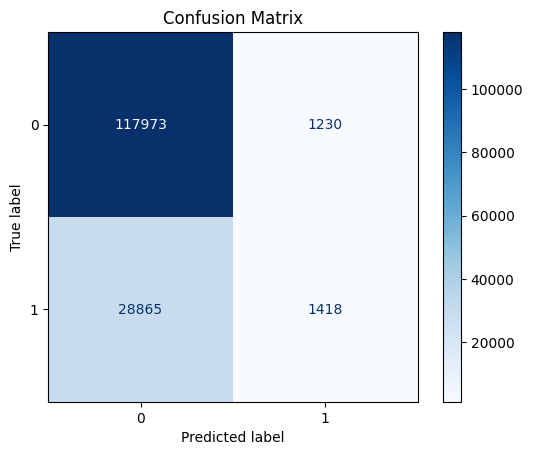

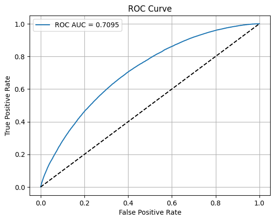

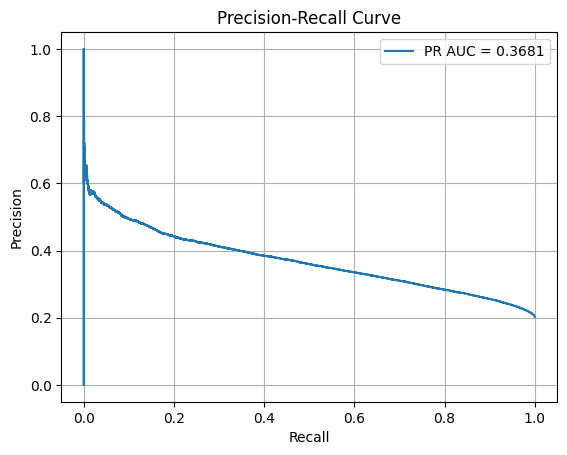

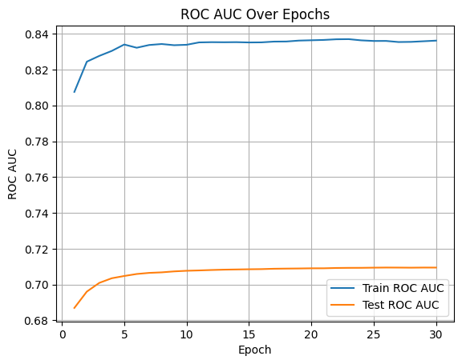

```python
import numpy as np
import pandas as pd
import matplotlib.pyplot as plt
from sklearn.ensemble import RandomForestClassifier
from sklearn.pipeline import Pipeline
from sklearn.impute import SimpleImputer
from sklearn.metrics import (
    roc_auc_score, average_precision_score,
    precision_score, recall_score, f1_score,
    confusion_matrix, ConfusionMatrixDisplay,
    roc_curve, precision_recall_curve
)

# 이미 준비된 데이터셋: X_train, X_test, y_train, y_test

# 최적 하이퍼파라미터 (Optuna 결과)
best_params_20 = {
    'n_estimators': 200,
    'max_depth': 20,
    'max_features': 'sqrt'
}

# 파이프라인 구성 (Imputer + RandomForest)
pipeline_20 = Pipeline([
    ('imputer', SimpleImputer(copy=False)),
    ('model', RandomForestClassifier(
        n_estimators=best_params_20['n_estimators'],
        max_depth=best_params_20['max_depth'],
        max_features=best_params_20['max_features'],
        n_jobs=-1,
        random_state=1
    ))
])

# === 에포크별 학습과 평가를 위한 준비 ===
# RandomForest는 warm_start=True로 설정해야 partial 학습 가능
pipeline_20.set_params(model__warm_start=True)
model_20 = pipeline_20.named_steps['model']

# imputer와 모델 분리 fit_transform을 먼저 진행
X_train_imp_20 = pipeline_20.named_steps['imputer'].fit_transform(X_train)
X_test_imp_20 = pipeline_20.named_steps['imputer'].transform(X_test)

epochs_20 = 30
train_roc_aucs_20 = []
test_roc_aucs_20 = []

for epoch_20 in range(1, epochs_20 + 1):
    model_20.n_estimators = epoch_20 * (best_params_20['n_estimators'] // epochs_20)
    if model_20.n_estimators == 0:
        model_20.n_estimators = 1  # 최소 1개
    model_20.fit(X_train_imp_20, y_train)

    # 예측확률
    y_train_pred_prob_20 = model_20.predict_proba(X_train_imp_20)[:, 1]
    y_test_pred_prob_20 = model_20.predict_proba(X_test_imp_20)[:, 1]

    # ROC AUC 저장
    train_roc_aucs_20.append(roc_auc_score(y_train, y_train_pred_prob_20))
    test_roc_aucs_20.append(roc_auc_score(y_test, y_test_pred_prob_20))

# === 최종 예측 및 다양한 지표 계산 ===
y_pred_prob_20 = model_20.predict_proba(X_test_imp_20)[:, 1]
y_pred_20 = model_20.predict(X_test_imp_20)

roc_auc_20 = roc_auc_score(y_test, y_pred_prob_20)
pr_auc_20 = average_precision_score(y_test, y_pred_prob_20)
precision_20 = precision_score(y_test, y_pred_20)
recall_20 = recall_score(y_test, y_pred_20)
f1_20 = f1_score(y_test, y_pred_20)
cm_20 = confusion_matrix(y_test, y_pred_20)

# === 결과 출력 ===
print(f"✅ ROC AUC: {roc_auc_20:.4f}")
print(f"✅ PR AUC: {pr_auc_20:.4f}")
print(f"✅ Precision: {precision_20:.4f}")
print(f"✅ Recall: {recall_20:.4f}")
print(f"✅ F1 Score: {f1_20:.4f}")
print("\n📊 Confusion Matrix:")
print(pd.DataFrame(
    cm_20,
    columns=['Predicted Neg', 'Predicted Pos'],
    index=['Actual Neg', 'Actual Pos']
))

# === Confusion Matrix 시각화 ===
disp_20 = ConfusionMatrixDisplay(confusion_matrix=cm_20)
disp_20.plot(cmap="Blues")
plt.title("Confusion Matrix")
plt.show()

# === ROC Curve ===
fpr_20, tpr_20, _ = roc_curve(y_test, y_pred_prob_20)
plt.plot(fpr_20, tpr_20, label=f"ROC AUC = {roc_auc_20:.4f}")
plt.plot([0, 1], [0, 1], 'k--')
plt.xlabel("False Positive Rate")
plt.ylabel("True Positive Rate")
plt.title("ROC Curve")
plt.legend()
plt.grid(True)
plt.show()

# === Precision-Recall Curve ===
prec_20, rec_20, _ = precision_recall_curve(y_test, y_pred_prob_20)
plt.plot(rec_20, prec_20, label=f"PR AUC = {pr_auc_20:.4f}")
plt.xlabel("Recall")
plt.ylabel("Precision")
plt.title("Precision-Recall Curve")
plt.legend()
plt.grid(True)
plt.show()

# === 학습 중 ROC AUC 변화 시각화 ===
plt.plot(range(1, epochs_20 + 1), train_roc_aucs_20, label="Train ROC AUC")
plt.plot(range(1, epochs_20 + 1), test_roc_aucs_20, label="Test ROC AUC")
plt.xlabel("Epoch")
plt.ylabel("ROC AUC")
plt.title("ROC AUC Over Epochs")
plt.legend()
plt.grid(True)
plt.show()
```

```
✅ ROC AUC: 0.7095
✅ PR AUC: 0.3681
✅ Precision: 0.5355
✅ Recall: 0.0468
✅ F1 Score: 0.0861

📊 Confusion Matrix:
            Predicted Neg  Predicted Pos
Actual Neg         117973           1230
Actual Pos          28865           1418
```

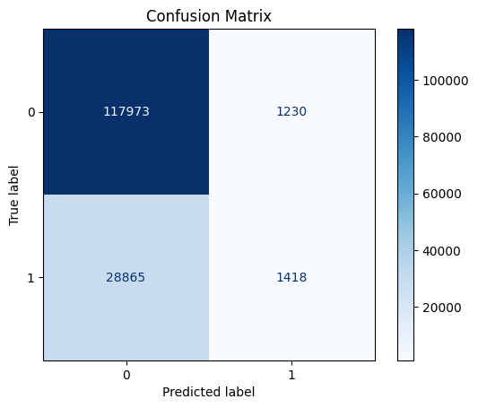

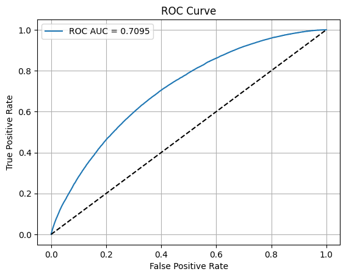

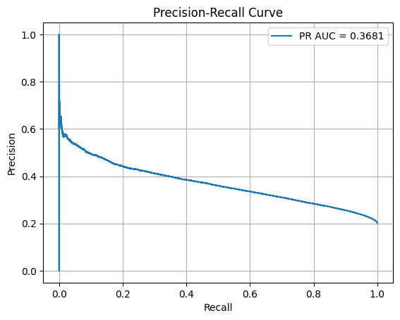

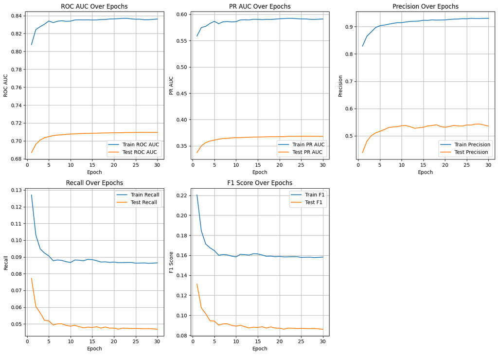

```python
import numpy as np
import pandas as pd
import matplotlib.pyplot as plt
from sklearn.ensemble import RandomForestClassifier
from sklearn.pipeline import Pipeline
from sklearn.impute import SimpleImputer
from sklearn.metrics import (
    roc_auc_score, average_precision_score,
    precision_score, recall_score, f1_score,
    confusion_matrix, ConfusionMatrixDisplay,
    roc_curve, precision_recall_curve
)

# ✅ 최적 하이퍼파라미터 (Optuna 결과)
best_params_20 = {
    'n_estimators': 200,
    'max_depth': 20,
    'max_features': 'sqrt'
}

# ✅ 파이프라인 구성 (전처리 + 모델)
pipeline_20 = Pipeline([
    ('imputer', SimpleImputer(copy=False)),
    ('model', RandomForestClassifier(
        n_estimators=best_params_20['n_estimators'],
        max_depth=best_params_20['max_depth'],
        max_features=best_params_20['max_features'],
        warm_start=True,
        n_jobs=-1,
        random_state=1
    ))
])

# ✅ 전처리 수동 수행
X_train_imp_20 = pipeline_20.named_steps['imputer'].fit_transform(X_train)
X_test_imp_20 = pipeline_20.named_steps['imputer'].transform(X_test)
model_20 = pipeline_20.named_steps['model']

# ✅ 지표 저장용 리스트 초기화
epochs_20 = 30
train_roc_aucs_20, test_roc_aucs_20 = [], []
train_pr_aucs_20, test_pr_aucs_20 = [], []
train_precisions_20, test_precisions_20 = [], []
train_recalls_20, test_recalls_20 = [], []
train_f1s_20, test_f1s_20 = [], []

# ✅ 반복 학습
for epoch_20 in range(1, epochs_20 + 1):
    model_20.n_estimators = epoch_20 * (best_params_20['n_estimators'] // epochs_20)
    model_20.fit(X_train_imp_20, y_train)

    y_train_prob = model_20.predict_proba(X_train_imp_20)[:, 1]
    y_test_prob = model_20.predict_proba(X_test_imp_20)[:, 1]
    y_train_pred = model_20.predict(X_train_imp_20)
    y_test_pred = model_20.predict(X_test_imp_20)

    # ✅ 지표 기록
    train_roc_aucs_20.append(roc_auc_score(y_train, y_train_prob))
    test_roc_aucs_20.append(roc_auc_score(y_test, y_test_prob))

    train_pr_aucs_20.append(average_precision_score(y_train, y_train_prob))
    test_pr_aucs_20.append(average_precision_score(y_test, y_test_prob))

    train_precisions_20.append(precision_score(y_train, y_train_pred))
    test_precisions_20.append(precision_score(y_test, y_test_pred))

    train_recalls_20.append(recall_score(y_train, y_train_pred))
    test_recalls_20.append(recall_score(y_test, y_test_pred))

    train_f1s_20.append(f1_score(y_train, y_train_pred))
    test_f1s_20.append(f1_score(y_test, y_test_pred))

# ✅ 최종 예측 및 평가
y_pred_prob_20 = model_20.predict_proba(X_test_imp_20)[:, 1]
y_pred_20 = model_20.predict(X_test_imp_20)

roc_auc_20 = roc_auc_score(y_test, y_pred_prob_20)
pr_auc_20 = average_precision_score(y_test, y_pred_prob_20)
precision_20 = precision_score(y_test, y_pred_20)
recall_20 = recall_score(y_test, y_pred_20)
f1_20 = f1_score(y_test, y_pred_20)
cm_20 = confusion_matrix(y_test, y_pred_20)

# ✅ 평가 출력
print(f"✅ ROC AUC: {roc_auc_20:.4f}")
print(f"✅ PR AUC: {pr_auc_20:.4f}")
print(f"✅ Precision: {precision_20:.4f}")
print(f"✅ Recall: {recall_20:.4f}")
print(f"✅ F1 Score: {f1_20:.4f}")

# ✅ Confusion Matrix 출력
print("\n📊 Confusion Matrix:")
print(pd.DataFrame(
    cm_20,
    columns=['Predicted Neg', 'Predicted Pos'],
    index=['Actual Neg', 'Actual Pos']
))

# ✅ Confusion Matrix 시각화
ConfusionMatrixDisplay(confusion_matrix=cm_20).plot(cmap="Blues")
plt.title("Confusion Matrix")
plt.show()

# ✅ ROC Curve
fpr_20, tpr_20, _ = roc_curve(y_test, y_pred_prob_20)
plt.plot(fpr_20, tpr_20, label=f"ROC AUC = {roc_auc_20:.4f}")
plt.plot([0, 1], [0, 1], 'k--')
plt.xlabel("False Positive Rate")
plt.ylabel("True Positive Rate")
plt.title("ROC Curve")
plt.legend()
plt.grid(True)
plt.show()

# ✅ Precision-Recall Curve
prec_20, rec_20, _ = precision_recall_curve(y_test, y_pred_prob_20)
plt.plot(rec_20, prec_20, label=f"PR AUC = {pr_auc_20:.4f}")
plt.xlabel("Recall")
plt.ylabel("Precision")
plt.title("Precision-Recall Curve")
plt.legend()
plt.grid(True)
plt.show()

# ✅ Epoch별 지표 시각화
epochs = range(1, epochs_20 + 1)
plt.figure(figsize=(14, 10))

plt.subplot(2, 3, 1)
plt.plot(epochs, train_roc_aucs_20, label='Train ROC AUC')
plt.plot(epochs, test_roc_aucs_20, label='Test ROC AUC')
plt.title('ROC AUC Over Epochs')
plt.xlabel('Epoch')
plt.ylabel('ROC AUC')
plt.legend()
plt.grid()

plt.subplot(2, 3, 2)
plt.plot(epochs, train_pr_aucs_20, label='Train PR AUC')
plt.plot(epochs, test_pr_aucs_20, label='Test PR AUC')
plt.title('PR AUC Over Epochs')
plt.xlabel('Epoch')
plt.ylabel('PR AUC')
plt.legend()
plt.grid()

plt.subplot(2, 3, 3)
plt.plot(epochs, train_precisions_20, label='Train Precision')
plt.plot(epochs, test_precisions_20, label='Test Precision')
plt.title('Precision Over Epochs')
plt.xlabel('Epoch')
plt.ylabel('Precision')
plt.legend()
plt.grid()

plt.subplot(2, 3, 4)
plt.plot(epochs, train_recalls_20, label='Train Recall')
plt.plot(epochs, test_recalls_20, label='Test Recall')
plt.title('Recall Over Epochs')
plt.xlabel('Epoch')
plt.ylabel('Recall')
plt.legend()
plt.grid()

plt.subplot(2, 3, 5)
plt.plot(epochs, train_f1s_20, label='Train F1')
plt.plot(epochs, test_f1s_20, label='Test F1')
plt.title('F1 Score Over Epochs')
plt.xlabel('Epoch')
plt.ylabel('F1 Score')
plt.legend()
plt.grid()

plt.tight_layout()
plt.show()
```

### (3) k-nearest neighbors

```python
# from sklearn.pipeline import Pipeline
# from sklearn.impute import SimpleImputer
# from sklearn.preprocessing import StandardScaler
# from sklearn.discriminant_analysis import LinearDiscriminantAnalysis
# from sklearn.neighbors import KNeighborsClassifier
# from sklearn.metrics import roc_auc_score

# # 이미 준비된 데이터
# # X_train, X_test, y_train, y_test

# # 최적 하이퍼파라미터 (Optuna 결과)
# best_params = {
#     'lda__n_components': 1,
#     'model__n_neighbors': 125
# }

# # 파이프라인 구성
# pipeline = Pipeline([
#     ('imputer', SimpleImputer(copy=False)),
#     ('scaler', StandardScaler(copy=False)),
#     ('lda', LinearDiscriminantAnalysis(n_components=best_params['lda__n_components'])),
#     ('model', KNeighborsClassifier(n_neighbors=best_params['model__n_neighbors'], n_jobs=-1))
# ])

# # 모델 학습
# pipeline.fit(X_train, y_train)

# # 테스트 데이터에 대해 확률 예측
# y_pred_proba = pipeline.predict_proba(X_test)[:, 1]

# # ROC AUC 평가
# auc = roc_auc_score(y_test, y_pred_proba)
# print(f"✅ Test ROC AUC: {auc:.4f}")
```

```
✅ ROC AUC: 0.6949
✅ PR AUC: 0.3480
✅ Precision: 0.4755
✅ Recall: 0.0804
✅ F1 Score: 0.1376

📊 Confusion Matrix:
            Predicted Neg  Predicted Pos
Actual Neg         116517           2686
Actual Pos          27848           2435
```

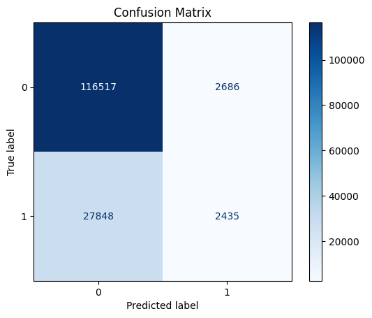

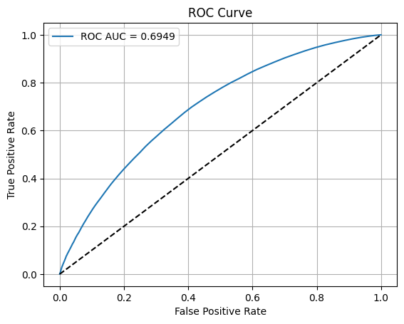

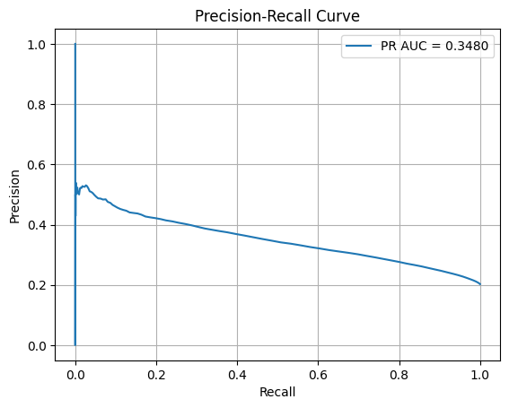

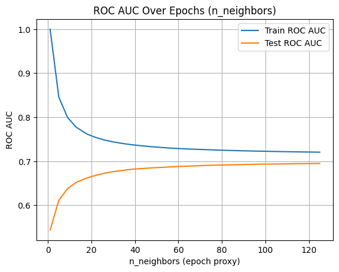

```python
import numpy as np
import pandas as pd
import matplotlib.pyplot as plt
from sklearn.pipeline import Pipeline
from sklearn.impute import SimpleImputer
from sklearn.preprocessing import StandardScaler
from sklearn.discriminant_analysis import LinearDiscriminantAnalysis
from sklearn.neighbors import KNeighborsClassifier
from sklearn.metrics import (
    roc_auc_score, average_precision_score,
    precision_score, recall_score, f1_score,
    confusion_matrix, ConfusionMatrixDisplay,
    roc_curve, precision_recall_curve
)

# 이미 준비된 데이터: X_train, X_test, y_train, y_test

# 최적 하이퍼파라미터 (Optuna 결과)
best_params_30 = {
    'lda__n_components': 1,
    'model__n_neighbors': 125
}

# 에포크 개념 흉내용 n_neighbors 리스트 (30단계)
neighbors_range_30 = np.linspace(1, best_params_30['model__n_neighbors'], 30, dtype=int)

# 성능 기록용 리스트
train_roc_aucs_30 = []
test_roc_aucs_30 = []

# Imputer와 Scaler 미리 적합 및 변환 (효율 위해)
imputer_30 = SimpleImputer(copy=False)
scaler_30 = StandardScaler(copy=False)

X_train_imp_30 = imputer_30.fit_transform(X_train)
X_test_imp_30 = imputer_30.transform(X_test)

X_train_scaled_30 = scaler_30.fit_transform(X_train_imp_30)
X_test_scaled_30 = scaler_30.transform(X_test_imp_30)

# LDA 변환기 적합 및 변환
lda_30 = LinearDiscriminantAnalysis(n_components=best_params_30['lda__n_components'])
X_train_lda_30 = lda_30.fit_transform(X_train_scaled_30, y_train)
X_test_lda_30 = lda_30.transform(X_test_scaled_30)

for n_neighbors_30 in neighbors_range_30:
    model_30 = KNeighborsClassifier(n_neighbors=n_neighbors_30, n_jobs=-1)
    model_30.fit(X_train_lda_30, y_train)

    # 예측 확률 (train/test)
    y_train_pred_prob_30 = model_30.predict_proba(X_train_lda_30)[:, 1]
    y_test_pred_prob_30 = model_30.predict_proba(X_test_lda_30)[:, 1]

    # ROC AUC 계산
    train_roc_aucs_30.append(roc_auc_score(y_train, y_train_pred_prob_30))
    test_roc_aucs_30.append(roc_auc_score(y_test, y_test_pred_prob_30))

# 최적 n_neighbors로 모델 재생성
model_30 = KNeighborsClassifier(n_neighbors=best_params_30['model__n_neighbors'], n_jobs=-1)
model_30.fit(X_train_lda_30, y_train)

y_pred_prob_30 = model_30.predict_proba(X_test_lda_30)[:, 1]
y_pred_30 = model_30.predict(X_test_lda_30)

roc_auc_30 = roc_auc_score(y_test, y_pred_prob_30)
pr_auc_30 = average_precision_score(y_test, y_pred_prob_30)
precision_30 = precision_score(y_test, y_pred_30)
recall_30 = recall_score(y_test, y_pred_30)
f1_30 = f1_score(y_test, y_pred_30)
cm_30 = confusion_matrix(y_test, y_pred_30)

# 결과 출력
print(f"✅ ROC AUC: {roc_auc_30:.4f}")
print(f"✅ PR AUC: {pr_auc_30:.4f}")
print(f"✅ Precision: {precision_30:.4f}")
print(f"✅ Recall: {recall_30:.4f}")
print(f"✅ F1 Score: {f1_30:.4f}")
print("\n📊 Confusion Matrix:")
print(pd.DataFrame(
    cm_30,
    columns=['Predicted Neg', 'Predicted Pos'],
    index=['Actual Neg', 'Actual Pos']
))

# Confusion Matrix 시각화
disp_30 = ConfusionMatrixDisplay(confusion_matrix=cm_30)
disp_30.plot(cmap="Blues")
plt.title("Confusion Matrix")
plt.show()

# ROC Curve 시각화
fpr_30, tpr_30, _ = roc_curve(y_test, y_pred_prob_30)
plt.plot(fpr_30, tpr_30, label=f"ROC AUC = {roc_auc_30:.4f}")
plt.plot([0, 1], [0, 1], 'k--')
plt.xlabel("False Positive Rate")
plt.ylabel("True Positive Rate")
plt.title("ROC Curve")
plt.legend()
plt.grid(True)
plt.show()

# Precision-Recall Curve 시각화
prec_30, rec_30, _ = precision_recall_curve(y_test, y_pred_prob_30)
plt.plot(rec_30, prec_30, label=f"PR AUC = {pr_auc_30:.4f}")
plt.xlabel("Recall")
plt.ylabel("Precision")
plt.title("Precision-Recall Curve")
plt.legend()
plt.grid(True)
plt.show()

# 에포크별 ROC AUC 변화 시각화
plt.plot(neighbors_range_30, train_roc_aucs_30, label="Train ROC AUC")
plt.plot(neighbors_range_30, test_roc_aucs_30, label="Test ROC AUC")
plt.xlabel("n_neighbors (epoch proxy)")
plt.ylabel("ROC AUC")
plt.title("ROC AUC Over Epochs (n_neighbors)")
plt.legend()
plt.grid(True)
plt.show()
```

```
✅ ROC AUC: 0.6949
✅ PR AUC: 0.3480
✅ Precision: 0.4755
✅ Recall: 0.0804
✅ F1 Score: 0.1376

📊 Confusion Matrix:
            Predicted Neg  Predicted Pos
Actual Neg         116517           2686
Actual Pos          27848           2435
```

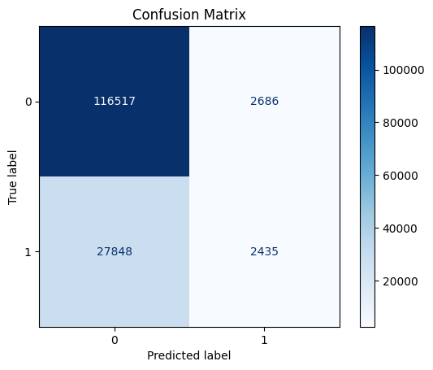

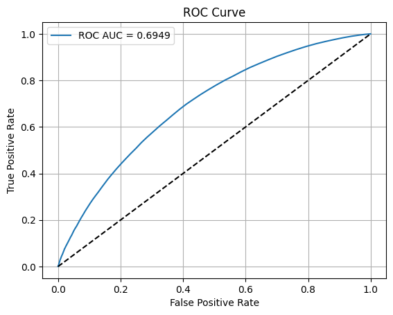

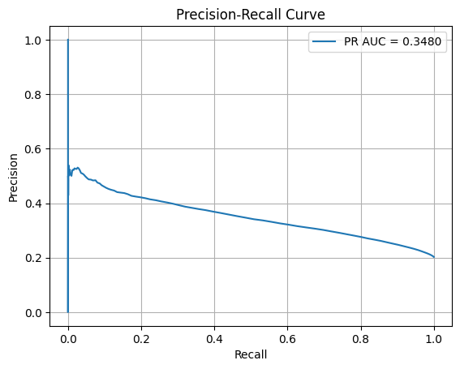

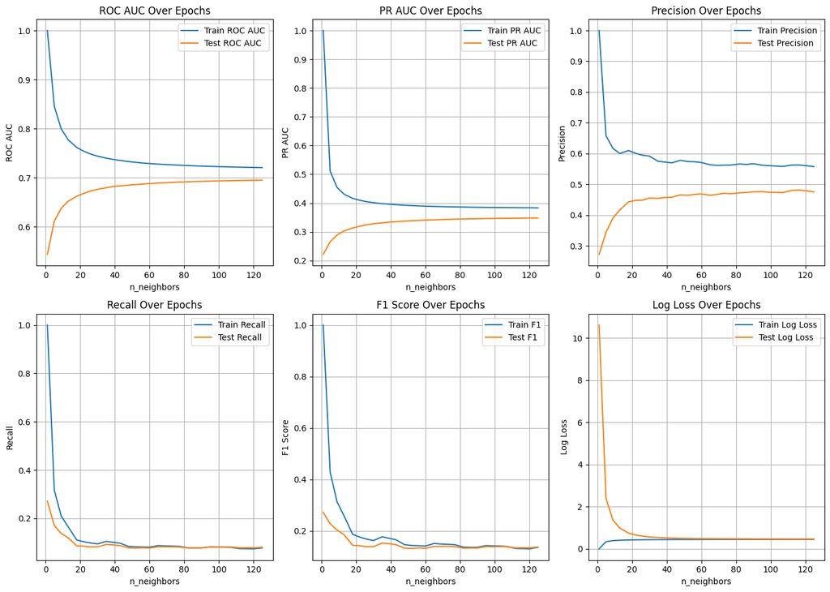

```python
import numpy as np
import pandas as pd
import matplotlib.pyplot as plt
from sklearn.pipeline import Pipeline
from sklearn.impute import SimpleImputer
from sklearn.preprocessing import StandardScaler
from sklearn.discriminant_analysis import LinearDiscriminantAnalysis
from sklearn.neighbors import KNeighborsClassifier
from sklearn.metrics import (
    roc_auc_score, average_precision_score,
    precision_score, recall_score, f1_score,
    confusion_matrix, ConfusionMatrixDisplay,
    roc_curve, precision_recall_curve,
    log_loss
)

# ✅ 최적 하이퍼파라미터
best_params_30 = {
    'lda__n_components': 1,
    'model__n_neighbors': 125
}

# ✅ n_neighbors 변화에 따른 "Epoch" 리스트
neighbors_range_30 = np.linspace(1, best_params_30['model__n_neighbors'], 30, dtype=int)

# ✅ 성능 기록용 리스트
train_roc_aucs_30, test_roc_aucs_30 = [], []
train_pr_aucs, test_pr_aucs = [], []
train_precisions, test_precisions = [], []
train_recalls, test_recalls = [], []
train_f1s, test_f1s = [], []
train_losses, test_losses = [], []

# ✅ 전처리
imputer_30 = SimpleImputer(copy=False)
scaler_30 = StandardScaler(copy=False)
X_train_scaled_30 = scaler_30.fit_transform(imputer_30.fit_transform(X_train))
X_test_scaled_30 = scaler_30.transform(imputer_30.transform(X_test))

lda_30 = LinearDiscriminantAnalysis(n_components=best_params_30['lda__n_components'])
X_train_lda_30 = lda_30.fit_transform(X_train_scaled_30, y_train)
X_test_lda_30 = lda_30.transform(X_test_scaled_30)

# ✅ 반복 학습 (에포크 = n_neighbors 수 증가)
for n_neighbors_30 in neighbors_range_30:
    model_30 = KNeighborsClassifier(n_neighbors=n_neighbors_30, n_jobs=-1)
    model_30.fit(X_train_lda_30, y_train)

    y_train_prob = model_30.predict_proba(X_train_lda_30)[:, 1]
    y_test_prob = model_30.predict_proba(X_test_lda_30)[:, 1]
    y_train_pred = model_30.predict(X_train_lda_30)
    y_test_pred = model_30.predict(X_test_lda_30)

    # ✅ 지표 기록
    train_roc_aucs_30.append(roc_auc_score(y_train, y_train_prob))
    test_roc_aucs_30.append(roc_auc_score(y_test, y_test_prob))

    train_pr_aucs.append(average_precision_score(y_train, y_train_prob))
    test_pr_aucs.append(average_precision_score(y_test, y_test_prob))

    train_precisions.append(precision_score(y_train, y_train_pred))
    test_precisions.append(precision_score(y_test, y_test_pred))

    train_recalls.append(recall_score(y_train, y_train_pred))
    test_recalls.append(recall_score(y_test, y_test_pred))

    train_f1s.append(f1_score(y_train, y_train_pred))
    test_f1s.append(f1_score(y_test, y_test_pred))

    train_losses.append(log_loss(y_train, y_train_prob))
    test_losses.append(log_loss(y_test, y_test_prob))

# ✅ 최종 평가 (최적 n_neighbors로 재적합)
model_30 = KNeighborsClassifier(n_neighbors=best_params_30['model__n_neighbors'], n_jobs=-1)
model_30.fit(X_train_lda_30, y_train)

y_pred_prob_30 = model_30.predict_proba(X_test_lda_30)[:, 1]
y_pred_30 = model_30.predict(X_test_lda_30)

roc_auc_30 = roc_auc_score(y_test, y_pred_prob_30)
pr_auc_30 = average_precision_score(y_test, y_pred_prob_30)
precision_30 = precision_score(y_test, y_pred_30)
recall_30 = recall_score(y_test, y_pred_30)
f1_30 = f1_score(y_test, y_pred_30)
cm_30 = confusion_matrix(y_test, y_pred_30)

# ✅ 결과 출력
print(f"✅ ROC AUC: {roc_auc_30:.4f}")
print(f"✅ PR AUC: {pr_auc_30:.4f}")
print(f"✅ Precision: {precision_30:.4f}")
print(f"✅ Recall: {recall_30:.4f}")
print(f"✅ F1 Score: {f1_30:.4f}")
print("\n📊 Confusion Matrix:")
print(pd.DataFrame(
    cm_30,
    columns=['Predicted Neg', 'Predicted Pos'],
    index=['Actual Neg', 'Actual Pos']
))

# ✅ Confusion Matrix 시각화
ConfusionMatrixDisplay(confusion_matrix=cm_30).plot(cmap="Blues")
plt.title("Confusion Matrix")
plt.show()

# ✅ ROC Curve 시각화
fpr_30, tpr_30, _ = roc_curve(y_test, y_pred_prob_30)
plt.plot(fpr_30, tpr_30, label=f"ROC AUC = {roc_auc_30:.4f}")
plt.plot([0, 1], [0, 1], 'k--')
plt.xlabel("False Positive Rate")
plt.ylabel("True Positive Rate")
plt.title("ROC Curve")
plt.legend()
plt.grid(True)
plt.show()

# ✅ Precision-Recall Curve 시각화
prec_30, rec_30, _ = precision_recall_curve(y_test, y_pred_prob_30)
plt.plot(rec_30, prec_30, label=f"PR AUC = {pr_auc_30:.4f}")
plt.xlabel("Recall")
plt.ylabel("Precision")
plt.title("Precision-Recall Curve")
plt.legend()
plt.grid(True)
plt.show()

# ✅ 에포크별 지표 시각화
epochs = neighbors_range_30
plt.figure(figsize=(14, 10))

plt.subplot(2, 3, 1)
plt.plot(epochs, train_roc_aucs_30, label='Train ROC AUC')
plt.plot(epochs, test_roc_aucs_30, label='Test ROC AUC')
plt.title('ROC AUC Over Epochs')
plt.xlabel('n_neighbors')
plt.ylabel('ROC AUC')
plt.legend()
plt.grid()

plt.subplot(2, 3, 2)
plt.plot(epochs, train_pr_aucs, label='Train PR AUC')
plt.plot(epochs, test_pr_aucs, label='Test PR AUC')
plt.title('PR AUC Over Epochs')
plt.xlabel('n_neighbors')
plt.ylabel('PR AUC')
plt.legend()
plt.grid()

plt.subplot(2, 3, 3)
plt.plot(epochs, train_precisions, label='Train Precision')
plt.plot(epochs, test_precisions, label='Test Precision')
plt.title('Precision Over Epochs')
plt.xlabel('n_neighbors')
plt.ylabel('Precision')
plt.legend()
plt.grid()

plt.subplot(2, 3, 4)
plt.plot(epochs, train_recalls, label='Train Recall')
plt.plot(epochs, test_recalls, label='Test Recall')
plt.title('Recall Over Epochs')
plt.xlabel('n_neighbors')
plt.ylabel('Recall')
plt.legend()
plt.grid()

plt.subplot(2, 3, 5)
plt.plot(epochs, train_f1s, label='Train F1')
plt.plot(epochs, test_f1s, label='Test F1')
plt.title('F1 Score Over Epochs')
plt.xlabel('n_neighbors')
plt.ylabel('F1 Score')
plt.legend()
plt.grid()

plt.subplot(2, 3, 6)
plt.plot(epochs, train_losses, label='Train Log Loss')
plt.plot(epochs, test_losses, label='Test Log Loss')
plt.title('Log Loss Over Epochs')
plt.xlabel('n_neighbors')
plt.ylabel('Log Loss')
plt.legend()
plt.grid()

plt.tight_layout()
plt.show()
```

### (4) 하이퍼파라미터 조정 or 다른 모델 선택

LightGBM (추천도 ★★★★★)

- ✅ 대용량 데이터에 최적화 (GPU 사용 가능)
- ✅ 범주형 변수 자동 처리
- ✅ 결측값 내재 처리
- ✅ 학습 속도 빠르고 성능 우수
- 🎯 AUROC 0.75~0.85 이상 기대 가능
- optuna.integration.lightgbm으로 자동 튜닝도 간편

```python
# # ✅ 최적 하이퍼파라미터 기반 LightGBM 모델 훈련 및 평가

# import lightgbm as lgb
# from sklearn.metrics import roc_auc_score

# # LightGBM Dataset 생성
# dtrain = lgb.Dataset(X_train, label=y_train)
# dvalid = lgb.Dataset(X_test, label=y_test)

# # ✅ 이전에 산출된 최적 하이퍼파라미터
# best_params = {
#     "objective": "binary",
#     "metric": "auc",
#     "verbosity": -1,
#     "boosting_type": "gbdt",
#     "n_jobs": -1,
#     "feature_pre_filter": False,
#     "lambda_l1": 0.0,
#     "lambda_l2": 0.0,
#     "num_leaves": 31,
#     "feature_fraction": 0.4,
#     "bagging_fraction": 1.0,
#     "bagging_freq": 0,
#     "min_child_samples": 20,
# }

# # 모델 학습
# model = lgb.train(
#     best_params,
#     train_set=dtrain,
#     valid_sets=[dvalid],
#     num_boost_round=1000,
#     callbacks=[
#         lgb.early_stopping(stopping_rounds=50),
#         lgb.log_evaluation(period=100)
#     ]
# )

# # 예측 및 평가
# y_pred = model.predict(X_test)
# auc = roc_auc_score(y_test, y_pred)
# print(f"✅ Final AUROC: {auc:.4f}")
```

```python
import lightgbm as lgb
from lightgbm import early_stopping, log_evaluation
import matplotlib.pyplot as plt
import numpy as np
import pandas as pd
from sklearn.metrics import (
    roc_auc_score, average_precision_score,
    precision_score, recall_score, f1_score,
    confusion_matrix, ConfusionMatrixDisplay,
    roc_curve, precision_recall_curve,
    log_loss
)

# LightGBM Dataset 생성
dtrain_40 = lgb.Dataset(X_train, label=y_train)
dvalid_40 = lgb.Dataset(X_test, label=y_test)

# 최적 하이퍼파라미터 (넘버링 40)
best_params_40 = {
    "objective": "binary",
    "metric": ["auc", "binary_logloss"],  # ✅ 추가
    "verbosity": -1,
    "boosting_type": "gbdt",
    "n_jobs": -1,
    "feature_pre_filter": False,
    "lambda_l1": 0.0,
    "lambda_l2": 0.0,
    "num_leaves": 31,
    "feature_fraction": 0.4,
    "bagging_fraction": 1.0,
    "bagging_freq": 0,
    "min_child_samples": 20,
}

# 기록용 리스트 초기화
evals_result_40 = {}

# 모델 학습 (evals_result에 train/valid 평가 기록 저장)
model_40 = lgb.train(
    best_params_40,
    train_set=dtrain_40,
    valid_sets=[dtrain_40, dvalid_40],
    valid_names=['train', 'valid'],
    num_boost_round=1000,
    callbacks=[
        early_stopping(stopping_rounds=50),
        log_evaluation(period=100)
    ],
    evals_result=evals_result_40
)

# 테스트 데이터 예측 (확률)
y_pred_prob_40 = model_40.predict(X_test)

# 이진 예측값 (threshold=0.5)
y_pred_40 = (y_pred_prob_40 >= 0.5).astype(int)

# 다양한 평가 지표 계산
roc_auc_40 = roc_auc_score(y_test, y_pred_prob_40)
pr_auc_40 = average_precision_score(y_test, y_pred_prob_40)
precision_40 = precision_score(y_test, y_pred_40)
recall_40 = recall_score(y_test, y_pred_40)
f1_40 = f1_score(y_test, y_pred_40)
cm_40 = confusion_matrix(y_test, y_pred_40)

print(f"✅ Test ROC AUC (roc_auc_40): {roc_auc_40:.4f}")
print(f"✅ Test PR AUC (pr_auc_40): {pr_auc_40:.4f}")
print(f"✅ Test Precision (precision_40): {precision_40:.4f}")
print(f"✅ Test Recall (recall_40): {recall_40:.4f}")
print(f"✅ Test F1 Score (f1_40): {f1_40:.4f}")
print("\n📊 Confusion Matrix (cm_40):")
print(pd.DataFrame(
    cm_40,
    columns=['Predicted Neg', 'Predicted Pos'],
    index=['Actual Neg', 'Actual Pos']
))

# Confusion Matrix 시각화
disp_40 = ConfusionMatrixDisplay(confusion_matrix=cm_40)
disp_40.plot(cmap="Blues")
plt.title("Confusion Matrix (Test Set)")
plt.show()

# ROC Curve 시각화
fpr_40, tpr_40, _ = roc_curve(y_test, y_pred_prob_40)
plt.plot(fpr_40, tpr_40, label=f"ROC AUC = {roc_auc_40:.4f}")
plt.plot([0, 1], [0, 1], 'k--')
plt.xlabel("False Positive Rate")
plt.ylabel("True Positive Rate")
plt.title("ROC Curve (Test Set)")
plt.legend()
plt.grid(True)
plt.show()

# Precision-Recall Curve 시각화
prec_40, rec_40, _ = precision_recall_curve(y_test, y_pred_prob_40)
plt.plot(rec_40, prec_40, label=f"PR AUC = {pr_auc_40:.4f}")
plt.xlabel("Recall")
plt.ylabel("Precision")
plt.title("Precision-Recall Curve (Test Set)")
plt.legend()
plt.grid(True)
plt.show()

# 훈련 시점별 평가 지표(roc_auc, logloss) 변화 선그래프 그리기

epochs_40 = range(1, len(evals_result_40['train']['auc']) + 1)

# Train/Test ROC AUC
plt.plot(epochs_40, evals_result_40['train']['auc'], label='Train ROC AUC')
plt.plot(epochs_40, evals_result_40['valid']['auc'], label='Valid ROC AUC')

plt.xlabel('Boosting Round')
plt.ylabel('AUC')
plt.title('ROC AUC over Training Rounds')
plt.legend()
plt.grid(True)
plt.show()

# Train/Test LogLoss
plt.plot(epochs_40, evals_result_40['train']['binary_logloss'], label='Train LogLoss')
plt.plot(epochs_40, evals_result_40['valid']['binary_logloss'], label='Valid LogLoss')

plt.xlabel('Boosting Round')
plt.ylabel('Log Loss')
plt.title('Log Loss over Training Rounds')
plt.legend()
plt.grid(True)
plt.show()
```

[output not shown]

```python
import lightgbm as lgb
import matplotlib.pyplot as plt
import numpy as np
import pandas as pd
from sklearn.metrics import (
    roc_auc_score, average_precision_score,
    precision_score, recall_score, f1_score,
    confusion_matrix, ConfusionMatrixDisplay,
    roc_curve, precision_recall_curve,
    log_loss
)

# ✅ LightGBM Dataset 생성
dtrain_40 = lgb.Dataset(X_train, label=y_train)
dvalid_40 = lgb.Dataset(X_test, label=y_test)

# ✅ 최적 하이퍼파라미터
best_params_40 = {
    "objective": "binary",
    "metric": ["auc", "binary_logloss"],
    "verbosity": -1,
    "boosting_type": "gbdt",
    "n_jobs": -1,
    "feature_pre_filter": False,
    "lambda_l1": 0.0,
    "lambda_l2": 0.0,
    "num_leaves": 31,
    "feature_fraction": 0.4,
    "bagging_fraction": 1.0,
    "bagging_freq": 0,
    "min_child_samples": 20,
}

# ✅ 기록용 리스트 초기화
evals_result_40 = {}
train_aucs_40, valid_aucs_40 = [], []
train_losses_40, valid_losses_40 = [], []
train_precisions, valid_precisions = [], []
train_recalls, valid_recalls = [], []
train_f1s, valid_f1s = [], []

# ✅ 콜백 정의: 매 epoch마다 metric 저장
def custom_callback(env):
    for i in range(len(env.evaluation_result_list)):
        data_name, eval_name, value, _ = env.evaluation_result_list[i]
        if eval_name == 'auc':
            if data_name == 'train':
                train_aucs_40.append(value)
            elif data_name == 'valid':
                valid_aucs_40.append(value)
        elif eval_name == 'binary_logloss':
            if data_name == 'train':
                train_losses_40.append(value)
            elif data_name == 'valid':
                valid_losses_40.append(value)

model_40 = lgb.train(
    best_params_40,
    train_set=dtrain_40,
    valid_sets=[dtrain_40, dvalid_40],
    valid_names=['train', 'valid'],
    num_boost_round=1000,
    early_stopping_rounds=50,
    callbacks=[custom_callback],
    evals_result=evals_result_40,
    verbose_eval=100
)

# ✅ 최종 예측값
y_pred_prob_40 = model_40.predict(X_test)
y_pred_40 = (y_pred_prob_40 >= 0.5).astype(int)
y_train_pred_prob_40 = model_40.predict(X_train)
y_train_pred_40 = (y_train_pred_prob_40 >= 0.5).astype(int)

# ✅ 정량 평가 (최종)
roc_auc_40 = roc_auc_score(y_test, y_pred_prob_40)
pr_auc_40 = average_precision_score(y_test, y_pred_prob_40)
precision_40 = precision_score(y_test, y_pred_40)
recall_40 = recall_score(y_test, y_pred_40)
f1_40 = f1_score(y_test, y_pred_40)
cm_40 = confusion_matrix(y_test, y_pred_40)

print(f"✅ ROC AUC: {roc_auc_40:.4f}")
print(f"✅ PR AUC: {pr_auc_40:.4f}")
print(f"✅ Precision: {precision_40:.4f}")
print(f"✅ Recall: {recall_40:.4f}")
print(f"✅ F1 Score: {f1_40:.4f}")

print("\n📊 Confusion Matrix:")
print(pd.DataFrame(
    cm_40,
    columns=['Predicted Neg', 'Predicted Pos'],
    index=['Actual Neg', 'Actual Pos']
))

# ✅ Confusion Matrix 시각화
ConfusionMatrixDisplay(confusion_matrix=cm_40).plot(cmap="Blues")
plt.title("Confusion Matrix (Test Set)")
plt.show()

# ✅ ROC Curve
fpr_40, tpr_40, _ = roc_curve(y_test, y_pred_prob_40)
plt.plot(fpr_40, tpr_40, label=f"ROC AUC = {roc_auc_40:.4f}")
plt.plot([0, 1], [0, 1], 'k--')
plt.xlabel("False Positive Rate")
plt.ylabel("True Positive Rate")
plt.title("ROC Curve")
plt.legend()
plt.grid(True)
plt.show()

# ✅ Precision-Recall Curve
prec_40, rec_40, _ = precision_recall_curve(y_test, y_pred_prob_40)
plt.plot(rec_40, prec_40, label=f"PR AUC = {pr_auc_40:.4f}")
plt.xlabel("Recall")
plt.ylabel("Precision")
plt.title("Precision-Recall Curve")
plt.legend()
plt.grid(True)
plt.show()

# ✅ Epoch별 성능 시각화 (같은 포맷)
epochs = range(1, len(train_aucs_40) + 1)
plt.figure(figsize=(14, 10))

plt.subplot(2, 3, 1)
plt.plot(epochs, train_aucs_40, label='Train ROC AUC')
plt.plot(epochs, valid_aucs_40, label='Valid ROC AUC')
plt.title('ROC AUC Over Epochs')
plt.xlabel('Epoch')
plt.ylabel('ROC AUC')
plt.legend()
plt.grid()

plt.subplot(2, 3, 2)
train_pr_aucs = [average_precision_score(y_train, (model_40.predict(X_train, num_iteration=i))) for i in epochs]
valid_pr_aucs = [average_precision_score(y_test, (model_40.predict(X_test, num_iteration=i))) for i in epochs]
plt.plot(epochs, train_pr_aucs, label='Train PR AUC')
plt.plot(epochs, valid_pr_aucs, label='Valid PR AUC')
plt.title('PR AUC Over Epochs')
plt.xlabel('Epoch')
plt.ylabel('PR AUC')
plt.legend()
plt.grid()

plt.subplot(2, 3, 3)
train_precisions = [precision_score(y_train, (model_40.predict(X_train, num_iteration=i) >= 0.5).astype(int)) for i in epochs]
valid_precisions = [precision_score(y_test, (model_40.predict(X_test, num_iteration=i) >= 0.5).astype(int)) for i in epochs]
plt.plot(epochs, train_precisions, label='Train Precision')
plt.plot(epochs, valid_precisions, label='Valid Precision')
plt.title('Precision Over Epochs')
plt.xlabel('Epoch')
plt.ylabel('Precision')
plt.legend()
plt.grid()

plt.subplot(2, 3, 4)
train_recalls = [recall_score(y_train, (model_40.predict(X_train, num_iteration=i) >= 0.5).astype(int)) for i in epochs]
valid_recalls = [recall_score(y_test, (model_40.predict(X_test, num_iteration=i) >= 0.5).astype(int)) for i in epochs]
plt.plot(epochs, train_recalls, label='Train Recall')
plt.plot(epochs, valid_recalls, label='Valid Recall')
plt.title('Recall Over Epochs')
plt.xlabel('Epoch')
plt.ylabel('Recall')
plt.legend()
plt.grid()

plt.subplot(2, 3, 5)
train_f1s = [f1_score(y_train, (model_40.predict(X_train, num_iteration=i) >= 0.5).astype(int)) for i in epochs]
valid_f1s = [f1_score(y_test, (model_40.predict(X_test, num_iteration=i) >= 0.5).astype(int)) for i in epochs]
plt.plot(epochs, train_f1s, label='Train F1')
plt.plot(epochs, valid_f1s, label='Valid F1')
plt.title('F1 Score Over Epochs')
plt.xlabel('Epoch')
plt.ylabel('F1 Score')
plt.legend()
plt.grid()

plt.subplot(2, 3, 6)
plt.plot(epochs, train_losses_40, label='Train Log Loss')
plt.plot(epochs, valid_losses_40, label='Valid Log Loss')
plt.title('Log Loss Over Epochs')
plt.xlabel('Epoch')
plt.ylabel('Log Loss')
plt.legend()
plt.grid()

plt.tight_layout()
plt.show()
```

### (4) 하이퍼파라미터 조정 or 다른 모델 선택

LightGBM (추천도 ★★★★★)

- ✅ 대용량 데이터에 최적화 (GPU 사용 가능)
- ✅ 범주형 변수 자동 처리
- ✅ 결측값 내재 처리
- ✅ 학습 속도 빠르고 성능 우수
- 🎯 AUROC 0.75~0.85 이상 기대 가능
- optuna.integration.lightgbm으로 자동 튜닝도 간편

```python
# 📌 1. 라이브러리 로드
import pandas as pd
import numpy as np
import lightgbm as lgb
import optuna.integration.lightgbm as lgb_optuna
from sklearn.metrics import roc_auc_score
from sklearn.preprocessing import LabelEncoder
from sklearn.model_selection import KFold

# 📌 3. LightGBM Dataset 생성
dtrain = lgb.Dataset(X_train, label=y_train)
dvalid = lgb.Dataset(X_test, label=y_test)

# 기본 파라미터 설정
params = {
    "objective": "binary",
    "metric": "auc",
    "verbosity": -1,
    "boosting_type": "gbdt",
    "n_jobs": -1,
}

folds = KFold(n_splits=5, shuffle=True, random_state=42)

tuner = lgb_optuna.LightGBMTunerCV(
    params,
    train_set=dtrain,
    folds=folds,  # 정수가 아닌 KFold 객체를 넘김
    num_boost_round=1000,
    time_budget=1800,
    seed=42,
    callbacks=[
        lgb.early_stopping(stopping_rounds=50),
        lgb.log_evaluation(period=100)
    ]
)

tuner.run()

best_params = tuner.best_params
best_params.update({
    "objective": "binary",
    "metric": "auc",
    "verbosity": -1,
})

final_model = lgb.train(
    best_params,
    train_set=dtrain,
    valid_sets=[dvalid],
    num_boost_round=1000,
    callbacks=[
        lgb.early_stopping(stopping_rounds=50),
        lgb.log_evaluation(period=100)
    ]
)

y_pred = final_model.predict(X_test)
auc = roc_auc_score(y_test, y_pred)
print(f"✅ Final AUROC: {auc:.4f}")
```